# SPL presentation

# Minimum Variance Portfolio

## Data

The data being used is provided by Kenneth French. The well known dataset ‘10 Industry Portfolios’ contains 10 portfolios of different US-companies.

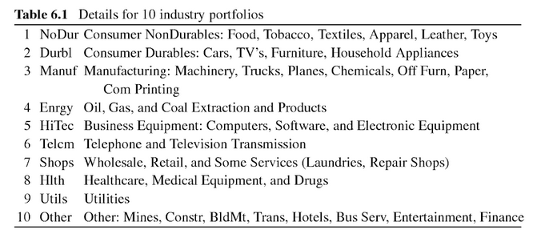

Explanation 10 Industry Portfolios

### Loading the data

Read ‘average value weighted returns (monthly)’ from line 12 to line 1121

|  | X | NoDur | Durbl | Manuf | Enrgy | HiTec | Telcm | Shops | Hlth | Utils | Other |
| --- | --- | --- | --- | --- | --- | --- | --- | --- | --- | --- | --- |
| 1 | 192607 | 1.45 | 15.55 | 4.69 | -1.18 | 2.90 | 0.83 | 0.11 | 1.77 | 7.04 | 2.16 |
| 2 | 192608 | 3.97 | 3.68 | 2.81 | 3.47 | 2.66 | 2.17 | -0.71 | 4.25 | -1.69 | 4.38 |
| 3 | 192609 | 1.14 | 4.80 | 1.15 | -3.39 | -0.38 | 2.41 | 0.21 | 0.69 | 2.04 | 0.29 |
| 4 | 192610 | -1.24 | -8.23 | -3.63 | -0.78 | -4.58 | -0.11 | -2.29 | -0.57 | -2.63 | -2.85 |
| 5 | 192611 | 5.21 | -0.19 | 4.10 | 0.01 | 4.71 | 1.63 | 6.43 | 5.42 | 3.71 | 2.11 |
| 6 | 192612 | 0.82 | 9.89 | 3.74 | 2.82 | -0.02 | 1.99 | 0.62 | 0.11 | -0.17 | 3.40 |

## Computing the Covariance Matrix

```r
cov_return_matrix
```

```
         NoDur    Durbl    Manuf    Enrgy    HiTec    Telcm    Shops     Hlth    Utils    Other
NoDur 20.87855 25.78169 24.03555 17.07151 24.18262 14.20811 22.88915 20.19569 17.73483 24.47136
Durbl 25.78169 58.57261 41.47241 28.62881 42.72165 22.05227 35.31515 26.98578 25.74777 39.43675
Manuf 24.03555 41.47241 38.69149 27.70223 38.67405 19.49894 30.59999 26.21504 23.66667 36.06344
Enrgy 17.07151 28.62881 27.70223 36.93934 26.80968 14.33150 20.70935 18.93730 20.35171 26.87643
HiTec 24.18262 42.72165 38.67405 26.80968 52.08515 22.47536 33.18733 28.85347 24.41621 36.87453
Telcm 14.20811 22.05227 19.49894 14.33150 22.47536 21.01664 18.00944 15.36386 15.80322 20.58528
Shops 22.88915 35.31515 30.59999 20.70935 33.18733 18.00944 33.67309 23.98317 20.68618 30.65570
Hlth  20.19569 26.98578 26.21504 18.93730 28.85347 15.36386 23.98317 30.89214 18.87372 26.22910
Utils 17.73483 25.74777 23.66667 20.35171 24.41621 15.80322 20.68618 18.87372 30.26306 25.25974
Other 24.47136 39.43675 36.06344 26.87643 36.87453 20.58528 30.65570 26.22910 25.25974 40.85289
```

All positive values in the cov_return_matrix, meaning there is at least some linear relation between all the values.

By evaluating the restrictions and definitions of the minimization-problem, you can define a Lagrangian, which can later be transposed into a linear system of equations of form
$$A \cdot x = b.$$
Since $A = \Sigma$ and $b = 1$ are known, we can solve this system to obtain $x = w_t.$

```r
b = vector(length=nA) + 1
x = solve(cov_return_matrix, b)
x = x/sum(x)
x
```

[output not shown]

Note that negative weights are interpreted as *short sales*.

## Performance anaylsis

To evaluate the performance, the analysis from deMiguel will be mimiced. DeMiguel et al. used a rolling-sample approach, where over a time period $T = 120$months, returns of the assets were being calculated. In each month $t$, starting form $t_0 = M + 1$, the data from the previous $M$ months was used to calculate the portfolio-weights $w_t$. By adding the return of the next period and dropping the earliest return, the whole dataset is processed, resulting in a series of $T - M$ monthly *out-of-sample* returns generated by each strategy.

```r
head(mu)
```

[output not shown]